# Stat 558 Project 1

Matthieu Cartron

9/10/2022

# Data Processing Initial

The following project is an exercise in data processing. Specifically, we will be processing data from the census bureau first using base R and tidyverse functions, and will subsequently nest/concatenate these functions into custom functions. The advantage in doing this is clear: the custom functions reduce the complexity and are more pragmatic.

## Reading in Data

First we want to bring the tidyverse package into the global environment so that we can call on its functions. Then we can use the readr function (part of the tidyverse) to read in the data from the url. We will store this as an object (sheet1) so that we can call upon it in the future. We can take a look at sheet1 by calling it.

```r
library(tidyverse)
sheet1 <- read_csv("https://www4.stat.ncsu.edu/~online/datasets/EDU01a.csv") # read in data with read_csv
sheet1 <- rename(sheet1, area_name = Area_name) # rename Area_name to area_name with rename()
sheet1
```

```
## # A tibble: 3,198 x 42
##    area_name     STCOU EDU010187F EDU010187D EDU010187N1 EDU010187N2 EDU010188F
##    <chr>         <chr>      <dbl>      <dbl> <chr>       <chr>            <dbl>
##  1 UNITED STATES 00000          0   40024299 0000        0000                 0
##  2 ALABAMA       01000          0     733735 0000        0000                 0
##  3 Autauga, AL   01001          0       6829 0000        0000                 0
##  4 Baldwin, AL   01003          0      16417 0000        0000                 0
##  5 Barbour, AL   01005          0       5071 0000        0000                 0
##  6 Bibb, AL      01007          0       3557 0000        0000                 0
##  7 Blount, AL    01009          0       7319 0000        0000                 0
##  8 Bullock, AL   01011          0       2014 0000        0000                 0
##  9 Butler, AL    01013          0       4640 0000        0000                 0
## 10 Calhoun, AL   01015          0      20939 0000        0000                 0
## # ... with 3,188 more rows, and 35 more variables: EDU010188D <dbl>,
## #   EDU010188N1 <chr>, EDU010188N2 <chr>, EDU010189F <dbl>, EDU010189D <dbl>,
## #   EDU010189N1 <chr>, EDU010189N2 <chr>, EDU010190F <dbl>, EDU010190D <dbl>,
## #   EDU010190N1 <chr>, EDU010190N2 <chr>, EDU010191F <dbl>, EDU010191D <dbl>,
## #   EDU010191N1 <chr>, EDU010191N2 <chr>, EDU010192F <dbl>, EDU010192D <dbl>,
## #   EDU010192N1 <chr>, EDU010192N2 <chr>, EDU010193F <dbl>, EDU010193D <dbl>,
## #   EDU010193N1 <chr>, EDU010193N2 <chr>, EDU010194F <dbl>, ...
```

## Select

Now we will subset our data by selecting (with select() from dplyr) Area_name, STCOU, and any column ending with an uppercase “D.” We can use the nested function ends_with to accomplish this.

```r
sheet1 <- sheet1 %>%
  select(area_name, STCOU, ends_with("D"))

sheet1 # let's have a look
```

```
## # A tibble: 3,198 x 12
##    area_name     STCOU EDU010187D EDU010188D EDU010189D EDU010190D EDU010191D
##    <chr>         <chr>      <dbl>      <dbl>      <dbl>      <dbl>      <dbl>
##  1 UNITED STATES 00000   40024299   39967624   40317775   40737600   41385442
##  2 ALABAMA       01000     733735     728234     730048     728252     725541
##  3 Autauga, AL   01001       6829       6900       6920       6847       7008
##  4 Baldwin, AL   01003      16417      16465      16799      17054      17479
##  5 Barbour, AL   01005       5071       5098       5068       5156       5173
##  6 Bibb, AL      01007       3557       3508       3571       3621       3652
##  7 Blount, AL    01009       7319       7223       7205       7209       7155
##  8 Bullock, AL   01011       2014       1980       1985       1983       1985
##  9 Butler, AL    01013       4640       4582       4610       4591       4544
## 10 Calhoun, AL   01015      20939      20923      20907      20849      20768
## # ... with 3,188 more rows, and 5 more variables: EDU010192D <dbl>,
## #   EDU010193D <dbl>, EDU010194D <dbl>, EDU010195D <dbl>, EDU010196D <dbl>
```

## Conversion to Long Format

To make our data more usable, we will now convert it into long format (each row is a single, unique observation) with pivot_longer() and store it as sheet2.

```r
sheet2 <- pivot_longer(sheet1, cols = c(EDU010187D:EDU010196D), names_to = "EDU", values_to = "Enrollment")
sheet2
```

```
## # A tibble: 31,980 x 4
##    area_name     STCOU EDU        Enrollment
##    <chr>         <chr> <chr>           <dbl>
##  1 UNITED STATES 00000 EDU010187D   40024299
##  2 UNITED STATES 00000 EDU010188D   39967624
##  3 UNITED STATES 00000 EDU010189D   40317775
##  4 UNITED STATES 00000 EDU010190D   40737600
##  5 UNITED STATES 00000 EDU010191D   41385442
##  6 UNITED STATES 00000 EDU010192D   42088151
##  7 UNITED STATES 00000 EDU010193D   42724710
##  8 UNITED STATES 00000 EDU010194D   43369917
##  9 UNITED STATES 00000 EDU010195D   43993459
## 10 UNITED STATES 00000 EDU010196D   44715737
## # ... with 31,970 more rows
```

## Separating EDU variables

We have an EDU variable and the enrollment value variable as a result of our transition to long format. We can extract some additional information from the EDU variable: the year and the measurement type. First we extract the year (as a part of EDU it is only the last two digits of the year) with base R’s substr(), which allows us to pull substrings from strings. It is stored as partial_year, to which we must now must convert to a four-digit year (e.e. 1995 instead of 95). We can do this with as.Date and specify the format we want with the format argument. What we end up with, however, is of the form “yyyy-mm-dd”. Thus we want to subset again, selecting the first four digits, and eliminate the hyphen with the function gsub(). We can then convert the class from character to numeric with as.numeric.

We can append this new “year’ object via mutate() to our data frame, creating the new variable”year.”

The final piece of information to extract is the measurement–the survey type and number. We can also do this with the substr() function, choosing but the first 7 characters of the string. And like with year, we will use mutate to append the survey type, measurement, to the data frame.

```r
#create four-digit year and make numeric. Store as "year."
partial_year <- substr(sheet2$EDU, 8, 9)
year <- as.numeric(substr(gsub("-", "", as.Date(partial_year, format = "%y")), 1, 4))

#add "year" to the data frame.
sheet3 <- sheet2 %>%
  mutate(year = year)


# Now grab first three characters and following four digits to create new variable representing which measurement was grabbed

survey_type <- substr(sheet3$EDU, 1, 7) # grabs first three characters and following four digits, then stores in object
sheet4 <- sheet3 %>%
  mutate(measurement = survey_type)

sheet4
```

```
## # A tibble: 31,980 x 6
##    area_name     STCOU EDU        Enrollment  year measurement
##    <chr>         <chr> <chr>           <dbl> <dbl> <chr>
##  1 UNITED STATES 00000 EDU010187D   40024299  1987 EDU0101
##  2 UNITED STATES 00000 EDU010188D   39967624  1988 EDU0101
##  3 UNITED STATES 00000 EDU010189D   40317775  1989 EDU0101
##  4 UNITED STATES 00000 EDU010190D   40737600  1990 EDU0101
##  5 UNITED STATES 00000 EDU010191D   41385442  1991 EDU0101
##  6 UNITED STATES 00000 EDU010192D   42088151  1992 EDU0101
##  7 UNITED STATES 00000 EDU010193D   42724710  1993 EDU0101
##  8 UNITED STATES 00000 EDU010194D   43369917  1994 EDU0101
##  9 UNITED STATES 00000 EDU010195D   43993459  1995 EDU0101
## 10 UNITED STATES 00000 EDU010196D   44715737  1996 EDU0101
## # ... with 31,970 more rows
```

## Create County and Non-county data sets

Now we want to create two data sets, one of county data and one for non-county data. If county is provided, it is listed before the state (e.g Barbour, AL). We can filter our data set and look for patterns to include only county and vice versa. The function grepl() will take a pattern (in this case: “, \w\w”) and filter for that pattern. We can pass a “!” to grepl to say that we *do not* want a given pattern.

Finally, for later use we will customize the classes of the newly created data frames. For county we created the county class and for non-county the state class (state is a little easier to work with, even if not all observations are state observations–some only say “United States”).

```r
county_data <- sheet4 %>%
  filter(grepl(", \\w\\w", sheet4$area_name))

noncounty_data <- sheet4 %>%
  filter(!grepl(", \\w\\w", sheet4$area_name))

# Add class to county tibble called county
class(county_data) <- c("county", class(county_data))

# Add class to state tibble called state

class(noncounty_data) <- c("state", class(noncounty_data))
```

## State Specification for County

For further clarity, we will create a new variable which_state from area_name telling us the state in which a county is located. We can take a substring from area_name with substr(), and take the last two characters with -2. Again to add a new variable to our county data frame we will use the mutate function.

```r
# create new variable (specifying the US state) extracting state the state abbreviation from area_name for the county data
county_data <- county_data %>%
  mutate(which_state = str_sub(area_name, -2))
```

## Division Variable for Non-county

For our non-county data frame we will now create a new variable specifying the census division of each state. We can accomplish this by creating a nested if statement. If a given area_name happens to be one of the states in (for the question “is it in?” we use the %in% operator) a particular division, it will get the value of the associated division (e.g “New England” for the states in the New England area), and if the area_name is not in that particular vector of states, we will ask the same question of that particular area_name for the next vector of states. If, by the end, an observation is not in any of the state vectors, the value that will be returned is “ERROR.” The nested if statement will be the function for the mutate function, which will create a new variable of the returned division values.

```r
noncounty_data <- noncounty_data %>%
  mutate(division = if_else(area_name %in% c("CONNECTICUT", "MAINE", "MASSACHUSETTS", "NEW HAMPSHIRE", "RHODE ISLAND", "VERMONT"), "New England",
         if_else(area_name %in% c("NEW YORK", "NEW JERSEY", "PENNSYLVANNIA"), "Mid-Atlantic",
         if_else(area_name %in% c("ILLINOIS", "INDIANA", "MICHIGAN", "OHIO", "WISCONSIN", "WISCONSIN"), "East North Central",
         if_else(area_name %in% c("IOWA", "KANSAS", "MINNESOTA", "MISSOURI", "NEBRASKA", "NORTH DAKOTA", "SOUTH DAKOTA"), "West North Central",
         if_else(area_name %in% c("DELAWARE", "FLORIDA", "GEORGIA", "MARYLAND", "NORTH CAROLINA", "SOUTH CAROLINA", "VIRGINIA", "DISTRICT OF COLUMBIA", "WEST VIRGINIA"), "South Atlantic",
         if_else(area_name %in% c("ALABAMA", "KENTUCKY", "MISSISSIPPI", "TENNESSEE"), "East South Central",
         if_else(area_name %in% c("ARKANSAS", "LOUISIANA", "OKLAHOMA", "TEXAS"), "West South Central",
         if_else(area_name %in% c("ARIZONA", "COLORADO", "IDAHO", "MONTANA", "NEVADA", "NEW MEXICO", "UTAH", "WYOMING"), "Mountain",
         if_else(area_name %in% c("ALASKA", "CALIFORNIA", "HAWAII", "OREGON", "WASHINGTON"), "Pacific", "ERROR"))))))))))
noncounty_data
```

```
## # A tibble: 530 x 7
##    area_name     STCOU EDU        Enrollment  year measurement division
##    <chr>         <chr> <chr>           <dbl> <dbl> <chr>       <chr>
##  1 UNITED STATES 00000 EDU010187D   40024299  1987 EDU0101     ERROR
##  2 UNITED STATES 00000 EDU010188D   39967624  1988 EDU0101     ERROR
##  3 UNITED STATES 00000 EDU010189D   40317775  1989 EDU0101     ERROR
##  4 UNITED STATES 00000 EDU010190D   40737600  1990 EDU0101     ERROR
##  5 UNITED STATES 00000 EDU010191D   41385442  1991 EDU0101     ERROR
##  6 UNITED STATES 00000 EDU010192D   42088151  1992 EDU0101     ERROR
##  7 UNITED STATES 00000 EDU010193D   42724710  1993 EDU0101     ERROR
##  8 UNITED STATES 00000 EDU010194D   43369917  1994 EDU0101     ERROR
##  9 UNITED STATES 00000 EDU010195D   43993459  1995 EDU0101     ERROR
## 10 UNITED STATES 00000 EDU010196D   44715737  1996 EDU0101     ERROR
## # ... with 520 more rows
```

# Custom/Generic Functions

We will now begin the process of creating custom functions that will eventually be able to complete the above steps with a single function call.

Again, we read in the data.

```r
# read in 2nd component of the data set

sheet1_comp2 <-read_csv("https://www4.stat.ncsu.edu/~online/datasets/EDU01b.csv")
sheet1_comp2
```

```
## # A tibble: 3,198 x 42
##    Area_name     STCOU EDU010197F EDU010197D EDU010197N1 EDU010197N2 EDU010198F
##    <chr>         <chr>      <dbl>      <dbl> <chr>       <chr>            <dbl>
##  1 UNITED STATES 00000          0   44534459 0000        0000                 0
##  2 ALABAMA       01000          0     737386 0000        0000                 0
##  3 Autauga, AL   01001          0       8099 0000        0000                 0
##  4 Baldwin, AL   01003          0      21410 0000        0000                 0
##  5 Barbour, AL   01005          0       5100 0000        0000                 0
##  6 Bibb, AL      01007          0       3717 0000        0000                 0
##  7 Blount, AL    01009          0       7816 0000        0000                 0
##  8 Bullock, AL   01011          0       2010 0000        0000                 0
##  9 Butler, AL    01013          0       4119 0000        0000                 0
## 10 Calhoun, AL   01015          0      19721 0000        0000                 0
## # ... with 3,188 more rows, and 35 more variables: EDU010198D <dbl>,
## #   EDU010198N1 <chr>, EDU010198N2 <chr>, EDU010199F <dbl>, EDU010199D <dbl>,
## #   EDU010199N1 <chr>, EDU010199N2 <chr>, EDU010200F <dbl>, EDU010200D <dbl>,
## #   EDU010200N1 <chr>, EDU010200N2 <chr>, EDU010201F <dbl>, EDU010201D <dbl>,
## #   EDU010201N1 <chr>, EDU010201N2 <chr>, EDU010202F <dbl>, EDU010202D <dbl>,
## #   EDU010202N1 <chr>, EDU010202N2 <chr>, EDU015203F <dbl>, EDU015203D <dbl>,
## #   EDU015203N1 <chr>, EDU015203N2 <chr>, EDU015204F <dbl>, ...
```

## long_select for select and format conversion.

Functions require arguments and manipulations of those objects (often other functions). A data object will consistently be our first argument (we are manipulating our data sets, after all), and we will want to give the user the flexibility of naming the enrollment value variable, though should they choose not to do so, the default argument is value = Enrollment (this is the second argument of the long-select() function). Within the function, we pass our arguments to the functions that we completed earlier when using built-in functions to convert to longer format and select area_name, STCOU, and variables ending in D.

```r
long_select <- function(data, value = Enrollment) {
  data <- rename(data, area_name = Area_name)
  data1 <- data %>%
  select(area_name, STCOU, ends_with("D"))
  pivot_longer(data1, cols = c(3:12), names_to = "EDU", values_to = "Enrollment")
}


long_select(sheet1_comp2)
```

```
## # A tibble: 31,980 x 4
##    area_name     STCOU EDU        Enrollment
##    <chr>         <chr> <chr>           <dbl>
##  1 UNITED STATES 00000 EDU010197D   44534459
##  2 UNITED STATES 00000 EDU010198D   46245814
##  3 UNITED STATES 00000 EDU010199D   46368903
##  4 UNITED STATES 00000 EDU010200D   46818690
##  5 UNITED STATES 00000 EDU010201D   47127066
##  6 UNITED STATES 00000 EDU010202D   47606570
##  7 UNITED STATES 00000 EDU015203D   48506317
##  8 UNITED STATES 00000 EDU015204D   48693287
##  9 UNITED STATES 00000 EDU015205D   48978555
## 10 UNITED STATES 00000 EDU015206D   49140702
## # ... with 31,970 more rows
```

## Parse1()

With parse1() we have the data argument again as well as our previous value argument (… will allow for the inclusion of arguments in the nested functions, including “value”). Long_select is nested within parse1 as well as are the functions that parse out the year, reformat it, append it as the new variable “year” and the functions that parse out the survey type and create the measurement type from it. An example is printed below the code chunk.

```r
parse1 <- function(data, ...) {
  data1 <- long_select(data)
  partial_year <- substr(data1$EDU, 8, 9)
  year <- as.numeric(substr(gsub("-", "", as.Date(partial_year, format = "%y")), 1, 4))
  data2 <- data1 %>%
    mutate(year = year)

  survey_type <- substr(data2$EDU, 1, 7)
  data3 <- data2 %>%
  mutate(measurement = survey_type)
}

print(parse1(sheet1_comp2))
```

```
## # A tibble: 31,980 x 6
##    area_name     STCOU EDU        Enrollment  year measurement
##    <chr>         <chr> <chr>           <dbl> <dbl> <chr>
##  1 UNITED STATES 00000 EDU010197D   44534459  1997 EDU0101
##  2 UNITED STATES 00000 EDU010198D   46245814  1998 EDU0101
##  3 UNITED STATES 00000 EDU010199D   46368903  1999 EDU0101
##  4 UNITED STATES 00000 EDU010200D   46818690  2000 EDU0102
##  5 UNITED STATES 00000 EDU010201D   47127066  2001 EDU0102
##  6 UNITED STATES 00000 EDU010202D   47606570  2002 EDU0102
##  7 UNITED STATES 00000 EDU015203D   48506317  2003 EDU0152
##  8 UNITED STATES 00000 EDU015204D   48693287  2004 EDU0152
##  9 UNITED STATES 00000 EDU015205D   48978555  2005 EDU0152
## 10 UNITED STATES 00000 EDU015206D   49140702  2006 EDU0152
## # ... with 31,970 more rows
```

## create_which_state()

Create_which_state() is our next customized function which parses out the state from the county data frame. Note that we did not do this until after we had created our county and non-county data frames, so why now? When we create our county and non-county data frames with custom functions, we will want to be able to add the division and which_state variables within the function, so we should do them ahead of time. The function create_which_state() takes in the county data frame as its first argument.

```r
create_which_state <- function(county_dat, ...) {
  county_dat %>%
    mutate(which_state = str_sub(area_name, -2))
}
```

## create_division

Below we create the function that will create the new variable “division” wherein the census divisions take different values (divisions) depending on the state’s division. Create_division() takes the non-county data frame as its first argument, and the mutate function uses the nested if statement (as we did before) to select divisions contingent upon the state division association.

```r
create_division <- function(noncounty_dat, ...) {
  noncounty_dat %>%
    mutate(division = if_else(area_name %in% c("CONNECTICUT", "MAINE", "MASSACHUSETTS", "NEW HAMPSHIRE", "RHODE ISLAND", "VERMONT"), "New England",
         if_else(area_name %in% c("NEW YORK", "NEW JERSEY", "PENNSYLVANNIA"), "Mid-Atlantic",
         if_else(area_name %in% c("ILLINOIS", "INDIANA", "MICHIGAN", "OHIO", "WISCONSIN", "WISCONSIN"), "East North Central",
         if_else(area_name %in% c("IOWA", "KANSAS", "MINNESOTA", "MISSOURI", "NEBRASKA", "NORTH DAKOTA", "SOUTH DAKOTA"), "West North Central",
         if_else(area_name %in% c("DELAWARE", "FLORIDA", "GEORGIA", "MARYLAND", "NORTH CAROLINA", "SOUTH CAROLINA", "VIRGINIA", "DISTRICT OF COLUMBIA", "WEST VIRGINIA"), "South Atlantic",
         if_else(area_name %in% c("ALABAMA", "KENTUCKY", "MISSISSIPPI", "TENNESSEE"), "East South Central",
         if_else(area_name %in% c("ARKANSAS", "LOUISIANA", "OKLAHOMA", "TEXAS"), "West South Central",
         if_else(area_name %in% c("ARIZONA", "COLORADO", "IDAHO", "MONTANA", "NEVADA", "NEW MEXICO", "UTAH", "WYOMING"), "Mountain",
         if_else(area_name %in% c("ALASKA", "CALIFORNIA", "HAWAII", "OREGON", "WASHINGTON"), "Pacific", "ERROR"))))))))))

}
```

## Create county and non-county data frames

Below almost everything comes together. With create_two_tibbles we want to create the county and state data frames.

The combined county and non-county data frames are passed as the first argument and are parsed with parse1(). From there area_names are sorted; with filter() and grepl(), as we did in the initial data processing section, we determine if an observation includes county and state data or just state (or United States). If the former, we assign the class “county”, and for the latter we assign the class “state.” For the county data frame, we then pass it through create_which_state to append the which_state variable. For the non-county data frame, we assign the “state” class and then pass it to the create_division() function to append the division values for each state (or “ERROR” if only “United States” is the value for area_names).

```r
create_two_tibbles <- function(data, ...){
  data1 <- parse1(data)
  county_data <- data1 %>%
    filter(grepl(", \\w\\w", data1$area_name))
  noncounty_data <- data1 %>%
    filter(!grepl(", \\w\\w", data1$area_name))
  class(county_data) <- c("county", class(county_data))
  class(noncounty_data) <- c("state", class(noncounty_data))
  county_data_tibble <- create_which_state(county_data)
  noncounty_data_tibble <- create_division(noncounty_data)

  return(list(result1 = county_data_tibble, result2 = noncounty_data_tibble))

}

create_two_tibbles(sheet1_comp2)
```

```
## $result1
## # A tibble: 31,450 x 7
##    area_name   STCOU EDU        Enrollment  year measurement which_state
##    <chr>       <chr> <chr>           <dbl> <dbl> <chr>       <chr>
##  1 Autauga, AL 01001 EDU010197D       8099  1997 EDU0101     AL
##  2 Autauga, AL 01001 EDU010198D       8211  1998 EDU0101     AL
##  3 Autauga, AL 01001 EDU010199D       8489  1999 EDU0101     AL
##  4 Autauga, AL 01001 EDU010200D       8912  2000 EDU0102     AL
##  5 Autauga, AL 01001 EDU010201D       8626  2001 EDU0102     AL
##  6 Autauga, AL 01001 EDU010202D       8762  2002 EDU0102     AL
##  7 Autauga, AL 01001 EDU015203D       9105  2003 EDU0152     AL
##  8 Autauga, AL 01001 EDU015204D       9200  2004 EDU0152     AL
##  9 Autauga, AL 01001 EDU015205D       9559  2005 EDU0152     AL
## 10 Autauga, AL 01001 EDU015206D       9652  2006 EDU0152     AL
## # ... with 31,440 more rows
##
## $result2
## # A tibble: 530 x 7
##    area_name     STCOU EDU        Enrollment  year measurement division
##    <chr>         <chr> <chr>           <dbl> <dbl> <chr>       <chr>
##  1 UNITED STATES 00000 EDU010197D   44534459  1997 EDU0101     ERROR
##  2 UNITED STATES 00000 EDU010198D   46245814  1998 EDU0101     ERROR
##  3 UNITED STATES 00000 EDU010199D   46368903  1999 EDU0101     ERROR
##  4 UNITED STATES 00000 EDU010200D   46818690  2000 EDU0102     ERROR
##  5 UNITED STATES 00000 EDU010201D   47127066  2001 EDU0102     ERROR
##  6 UNITED STATES 00000 EDU010202D   47606570  2002 EDU0102     ERROR
##  7 UNITED STATES 00000 EDU015203D   48506317  2003 EDU0152     ERROR
##  8 UNITED STATES 00000 EDU015204D   48693287  2004 EDU0152     ERROR
##  9 UNITED STATES 00000 EDU015205D   48978555  2005 EDU0152     ERROR
## 10 UNITED STATES 00000 EDU015206D   49140702  2006 EDU0152     ERROR
## # ... with 520 more rows
```

## Wrapper function

Now everything comes together. The only function missing from create_two_tibbles is the read_csv() that we use initially to bring the data into the global environment! Because the data frame does not yet exist without it first being called with read_csv(), our first argument must be the url which is passed to read_csv(). For our final function we again want to provide flexibility for the user and allow for the enrollment value’s variable name to be customizable. It is thus our second argument. The function returns (with “return”) a list of two results: the first the county data frame (tibble) and the second the non-county data frame (tibble).

Let’s also clean up our results and make them easier to understand. Instead of having result1 and result2, lets turn them into countytibb and statetibb, as this will allow us to distinguish between the two without having to look at them more closely.

```r
my_wrapper <- function(url, value = "Enrollment") {
  data <- read_csv(url)
    data1 <- parse1(data)
  county_data <- data1 %>%
    filter(grepl(", \\w\\w", data1$area_name))
  noncounty_data <- data1 %>%
    filter(!grepl(", \\w\\w", data1$area_name))
  class(county_data) <- c("county", class(county_data))
  class(noncounty_data) <- c("state", class(noncounty_data))
  county_data_tibble <- create_which_state(county_data)
  noncounty_data_tibble <- create_division(noncounty_data)

  return(list(countytibb = county_data_tibble, statetibb = noncounty_data_tibble))
}
```

## Call and Combine Data

We can now test our our wrapper function on the two .csv files provided thus far.

```r
# now call wrapper function on the two data sets
wrap1 <- my_wrapper("https://www4.stat.ncsu.edu/~online/datasets/EDU01a.csv")
wrap2 <- my_wrapper("https://www4.stat.ncsu.edu/~online/datasets/EDU01b.csv")
wrap1
```

```
## $countytibb
## # A tibble: 31,450 x 7
##    area_name   STCOU EDU        Enrollment  year measurement which_state
##    <chr>       <chr> <chr>           <dbl> <dbl> <chr>       <chr>
##  1 Autauga, AL 01001 EDU010187D       6829  1987 EDU0101     AL
##  2 Autauga, AL 01001 EDU010188D       6900  1988 EDU0101     AL
##  3 Autauga, AL 01001 EDU010189D       6920  1989 EDU0101     AL
##  4 Autauga, AL 01001 EDU010190D       6847  1990 EDU0101     AL
##  5 Autauga, AL 01001 EDU010191D       7008  1991 EDU0101     AL
##  6 Autauga, AL 01001 EDU010192D       7137  1992 EDU0101     AL
##  7 Autauga, AL 01001 EDU010193D       7152  1993 EDU0101     AL
##  8 Autauga, AL 01001 EDU010194D       7381  1994 EDU0101     AL
##  9 Autauga, AL 01001 EDU010195D       7568  1995 EDU0101     AL
## 10 Autauga, AL 01001 EDU010196D       7834  1996 EDU0101     AL
## # ... with 31,440 more rows
##
## $statetibb
## # A tibble: 530 x 7
##    area_name     STCOU EDU        Enrollment  year measurement division
##    <chr>         <chr> <chr>           <dbl> <dbl> <chr>       <chr>
##  1 UNITED STATES 00000 EDU010187D   40024299  1987 EDU0101     ERROR
##  2 UNITED STATES 00000 EDU010188D   39967624  1988 EDU0101     ERROR
##  3 UNITED STATES 00000 EDU010189D   40317775  1989 EDU0101     ERROR
##  4 UNITED STATES 00000 EDU010190D   40737600  1990 EDU0101     ERROR
##  5 UNITED STATES 00000 EDU010191D   41385442  1991 EDU0101     ERROR
##  6 UNITED STATES 00000 EDU010192D   42088151  1992 EDU0101     ERROR
##  7 UNITED STATES 00000 EDU010193D   42724710  1993 EDU0101     ERROR
##  8 UNITED STATES 00000 EDU010194D   43369917  1994 EDU0101     ERROR
##  9 UNITED STATES 00000 EDU010195D   43993459  1995 EDU0101     ERROR
## 10 UNITED STATES 00000 EDU010196D   44715737  1996 EDU0101     ERROR
## # ... with 520 more rows
```

```r
wrap2
```

```
## $countytibb
## # A tibble: 31,450 x 7
##    area_name   STCOU EDU        Enrollment  year measurement which_state
##    <chr>       <chr> <chr>           <dbl> <dbl> <chr>       <chr>
##  1 Autauga, AL 01001 EDU010197D       8099  1997 EDU0101     AL
##  2 Autauga, AL 01001 EDU010198D       8211  1998 EDU0101     AL
##  3 Autauga, AL 01001 EDU010199D       8489  1999 EDU0101     AL
##  4 Autauga, AL 01001 EDU010200D       8912  2000 EDU0102     AL
##  5 Autauga, AL 01001 EDU010201D       8626  2001 EDU0102     AL
##  6 Autauga, AL 01001 EDU010202D       8762  2002 EDU0102     AL
##  7 Autauga, AL 01001 EDU015203D       9105  2003 EDU0152     AL
##  8 Autauga, AL 01001 EDU015204D       9200  2004 EDU0152     AL
##  9 Autauga, AL 01001 EDU015205D       9559  2005 EDU0152     AL
## 10 Autauga, AL 01001 EDU015206D       9652  2006 EDU0152     AL
## # ... with 31,440 more rows
##
## $statetibb
## # A tibble: 530 x 7
##    area_name     STCOU EDU        Enrollment  year measurement division
##    <chr>         <chr> <chr>           <dbl> <dbl> <chr>       <chr>
##  1 UNITED STATES 00000 EDU010197D   44534459  1997 EDU0101     ERROR
##  2 UNITED STATES 00000 EDU010198D   46245814  1998 EDU0101     ERROR
##  3 UNITED STATES 00000 EDU010199D   46368903  1999 EDU0101     ERROR
##  4 UNITED STATES 00000 EDU010200D   46818690  2000 EDU0102     ERROR
##  5 UNITED STATES 00000 EDU010201D   47127066  2001 EDU0102     ERROR
##  6 UNITED STATES 00000 EDU010202D   47606570  2002 EDU0102     ERROR
##  7 UNITED STATES 00000 EDU015203D   48506317  2003 EDU0152     ERROR
##  8 UNITED STATES 00000 EDU015204D   48693287  2004 EDU0152     ERROR
##  9 UNITED STATES 00000 EDU015205D   48978555  2005 EDU0152     ERROR
## 10 UNITED STATES 00000 EDU015206D   49140702  2006 EDU0152     ERROR
## # ... with 520 more rows
```

Great! Both create a pair of tibbles with all of the information that we want.

## combine_tibbles()

The last custom function we want to create is one that will combine data frames of like classes from different data objects. From the two above URLs, for example, we will get two pairs of data frames, that is a state and county tibble for one URL and a state and county tibble for the other URL. Both URLs contain the same data format initially, so we can combine like classes to merge our four tibbles into two tibbles.

The function bind_rows will accomplish this. We can pass both county and state tibbles (in the function as arguments) to bind_rows.

```r
combine_tibbles <- function(wrap1, wrap2) {
  data_object_county <- bind_rows(wrap1$countytibb, wrap2$countytibb)
  data_object_state <- bind_rows(wrap1$statetibb, wrap2$statetibb)
  return(list(county = data_object_county, state = data_object_state))
}
County_State_Tibble <- combine_tibbles(wrap1, wrap2)
County_State_Tibble
```

```
## $county
## # A tibble: 62,900 x 7
##    area_name   STCOU EDU        Enrollment  year measurement which_state
##    <chr>       <chr> <chr>           <dbl> <dbl> <chr>       <chr>
##  1 Autauga, AL 01001 EDU010187D       6829  1987 EDU0101     AL
##  2 Autauga, AL 01001 EDU010188D       6900  1988 EDU0101     AL
##  3 Autauga, AL 01001 EDU010189D       6920  1989 EDU0101     AL
##  4 Autauga, AL 01001 EDU010190D       6847  1990 EDU0101     AL
##  5 Autauga, AL 01001 EDU010191D       7008  1991 EDU0101     AL
##  6 Autauga, AL 01001 EDU010192D       7137  1992 EDU0101     AL
##  7 Autauga, AL 01001 EDU010193D       7152  1993 EDU0101     AL
##  8 Autauga, AL 01001 EDU010194D       7381  1994 EDU0101     AL
##  9 Autauga, AL 01001 EDU010195D       7568  1995 EDU0101     AL
## 10 Autauga, AL 01001 EDU010196D       7834  1996 EDU0101     AL
## # ... with 62,890 more rows
##
## $state
## # A tibble: 1,060 x 7
##    area_name     STCOU EDU        Enrollment  year measurement division
##    <chr>         <chr> <chr>           <dbl> <dbl> <chr>       <chr>
##  1 UNITED STATES 00000 EDU010187D   40024299  1987 EDU0101     ERROR
##  2 UNITED STATES 00000 EDU010188D   39967624  1988 EDU0101     ERROR
##  3 UNITED STATES 00000 EDU010189D   40317775  1989 EDU0101     ERROR
##  4 UNITED STATES 00000 EDU010190D   40737600  1990 EDU0101     ERROR
##  5 UNITED STATES 00000 EDU010191D   41385442  1991 EDU0101     ERROR
##  6 UNITED STATES 00000 EDU010192D   42088151  1992 EDU0101     ERROR
##  7 UNITED STATES 00000 EDU010193D   42724710  1993 EDU0101     ERROR
##  8 UNITED STATES 00000 EDU010194D   43369917  1994 EDU0101     ERROR
##  9 UNITED STATES 00000 EDU010195D   43993459  1995 EDU0101     ERROR
## 10 UNITED STATES 00000 EDU010196D   44715737  1996 EDU0101     ERROR
## # ... with 1,050 more rows
```

# Writing a Generic Function for Summarizing

## State Plot

Finally, we pass our variables to the ggplot() function to create a line graph (additional function geom_line() specifies this). Year is on the x axis, mean enrollment on the y axis, and division is represented by color.

```
## Note: Using an external vector in selections is ambiguous.
## i Use `all_of(value)` instead of `value` to silence this message.
## i See <https://tidyselect.r-lib.org/reference/faq-external-vector.html>.
```

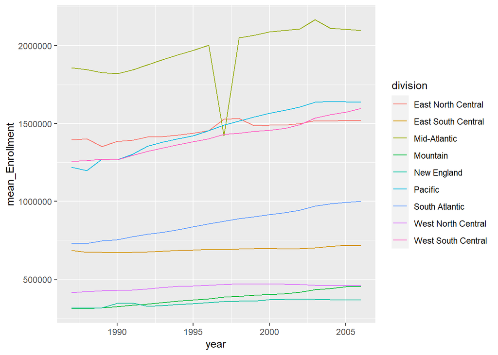

```r
plot.state <- function(df, value = "Enrollment") {
df_1 <- subset(df, division != "ERROR")
df_2 <- df_1 %>%
  select(year, division, value) %>%
  group_by(division, year) %>%
  summarise(mean_Enrollment = mean(get(value)))

ggplot(df_2, aes(x = year, y = mean_Enrollment, color = division)) +
geom_line()


}

plot.state(County_State_Tibble$state)
```

## Second Plot

Now let’s create a line graph for the county data. For this plot, however, we want to find the mean of enrollment for each area name and sort those values from largest to smallest depending on the value of a custom argument top or bottom. We’ll go with top (which will also allow us to specify values at the bottom with negative numbers). We also want to have a custom argument that will allow us to select a specific state.

After we have done the above, we want to filter area_names to only include area names returned from the above. How do we do all of this?

- select our variables of interest
- filter so that which_state is assigned to the state provided in the state argument
- group by area name
- create new variable mean_Enrollment with summarize()
- arrange mean enrollment in descending order
- look only at the top values with top_n() specified in the top argument–after this step we have what we want for this subsetted data frame, and we assign it to df_1
- create a new, separate data frame df_2 from df_1 that only contains the area names from df_1
- convert this new data frame, df_2, into a vector (we can do this because it is one-dimensional). This will make it easier to work with
- then we take our original data frame, df, that we passed into the plot.county function, select the variables of interest, and filter so that we include only area names that were in df_2. We will store this as df_3

After we complete the above steps, we can pass df_3 to ggplot, select our desired variables, and call geom_line() to specify a line graph.

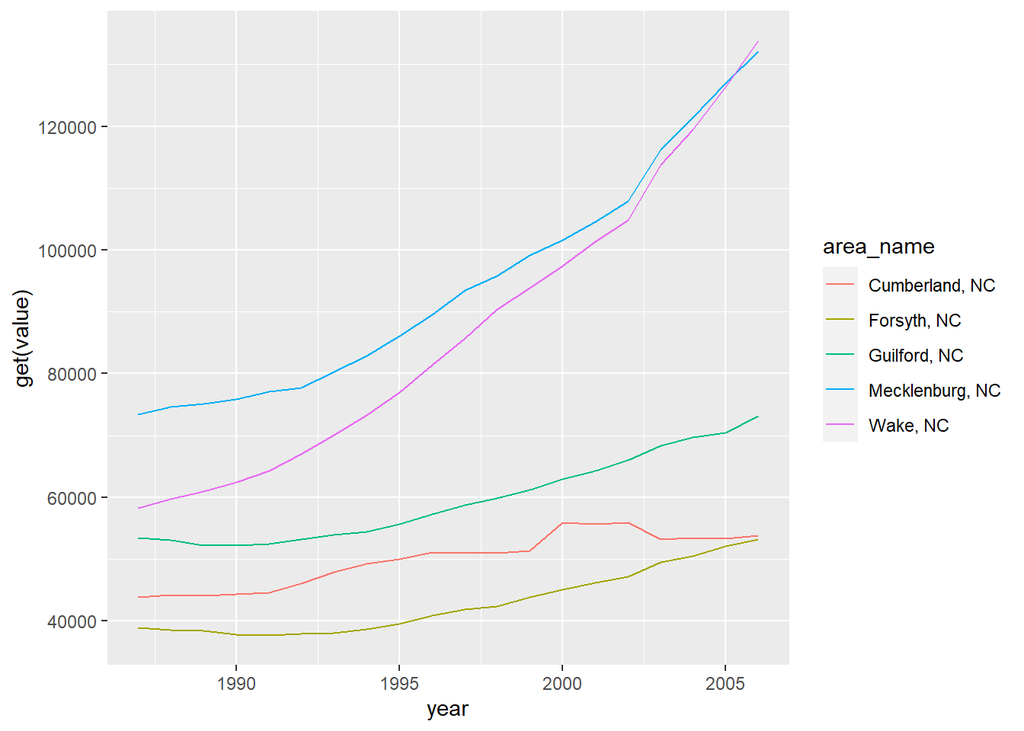

```r
plot.county <- function(df, state = "NM", top = 5, value = "Enrollment") {
df_1 <- df %>%
  select(area_name, which_state, year, value) %>%
  filter(which_state == state) %>%
  group_by(area_name) %>%
  summarise(mean_Enrollment = mean(get(value))) %>%
  arrange(desc(mean_Enrollment)) %>%
  top_n(top)

df_2 <- df_1 %>%
  select(area_name)

vectortop <- as.vector(df_2)

df_3 <- df %>%
  select(area_name, year, value) %>%
  filter(area_name %in% df_2$area_name)



ggplot(df_3, aes(x = year, y = get(value), color = area_name)) +
geom_line()

}

plot.county(County_State_Tibble$county, state = "NC", top = 5, value = "Enrollment")
```

# Put it Together

Let’s now put all of the above to the test. Let’s first run our wrapper function again onto the two initially provided .csv files (data sets).

## Initial URLs

```r
# Run data processing function on two first-given urls

tib1 <- my_wrapper("https://www4.stat.ncsu.edu/~online/datasets/EDU01a.csv")
tib2 <- my_wrapper("https://www4.stat.ncsu.edu/~online/datasets/EDU01b.csv")
```

## Combined initial URLS

Now we can combine the two processed tibbles with combine_tibbles() that we created earlier.

```r
combined_tib <- combine_tibbles(tib1, tib2)
```

## Plot state tibble

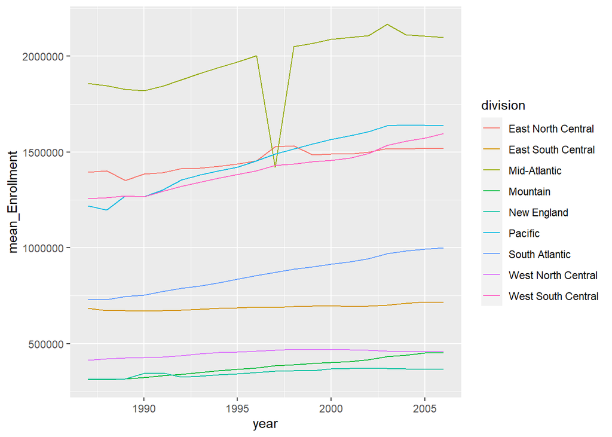

```r
plot.state(combined_tib$state)
```

Our plot for the state tibble works. We have our year (x), mean enrollment (y), and division by color.

## Test arguments

- Let’s test our arguments. First let’s specify the state to be “PA”, and to look at the top 7 counties for mean enrollment.
- Next let’s look again at Pennsylvania, but this time the bottom four counties (by mean enrollment).
- Now let’s plot countties without specifying any arguments (other than the required data object).
- Finally, let’s look at Minnesota (“MN”) and the top ten counties for mean enrollment.

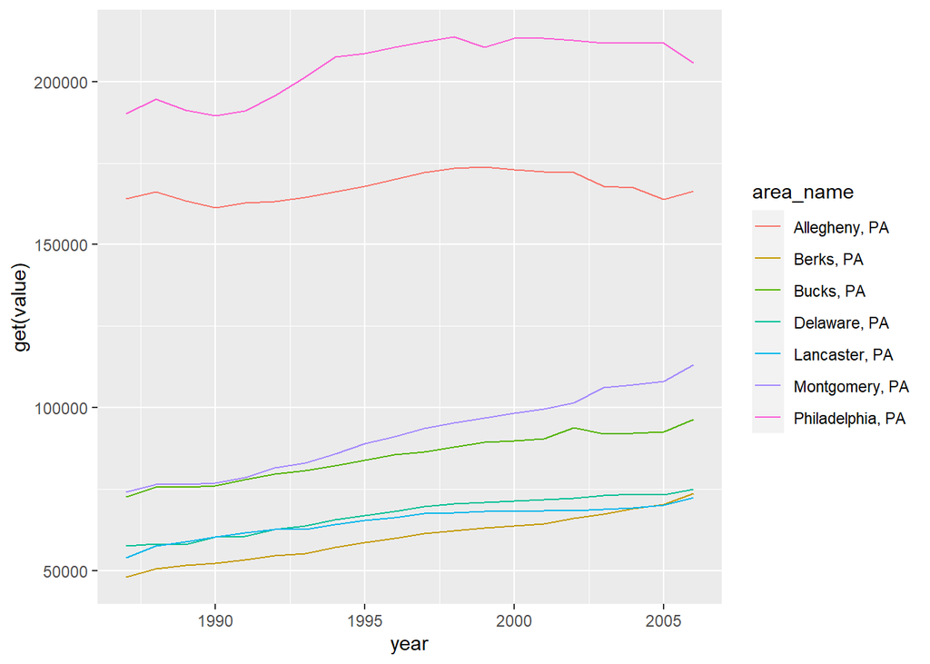

```r
# now apply plot.county function to the county tibble
plot.county(combined_tib$county, state = "PA", top = 7)
```

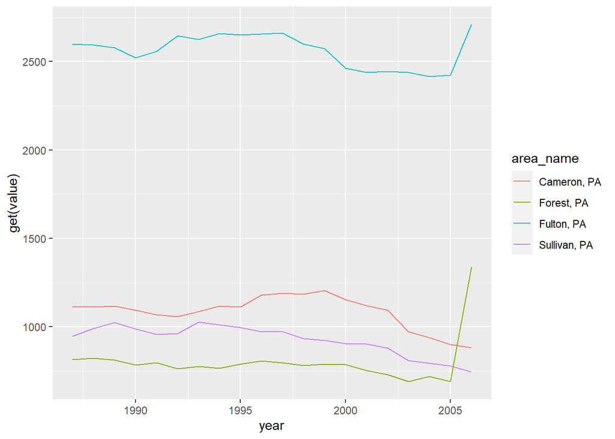

```r
plot.county(combined_tib$county, state = "PA", top = -4)
```

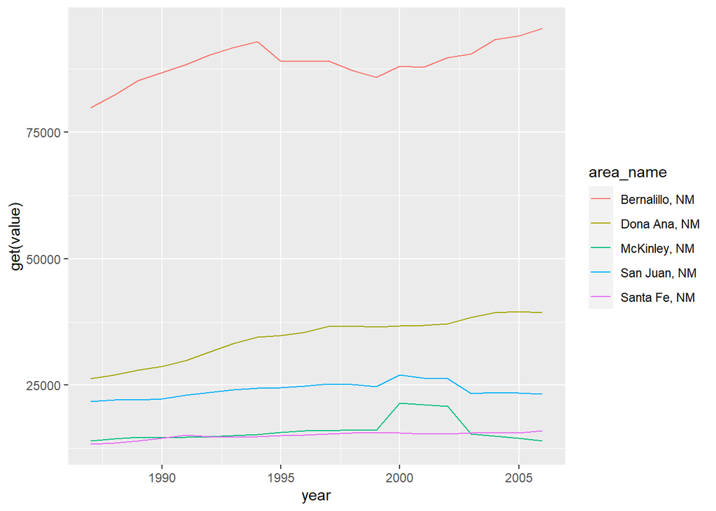

```r
plot.county(combined_tib$county)
```

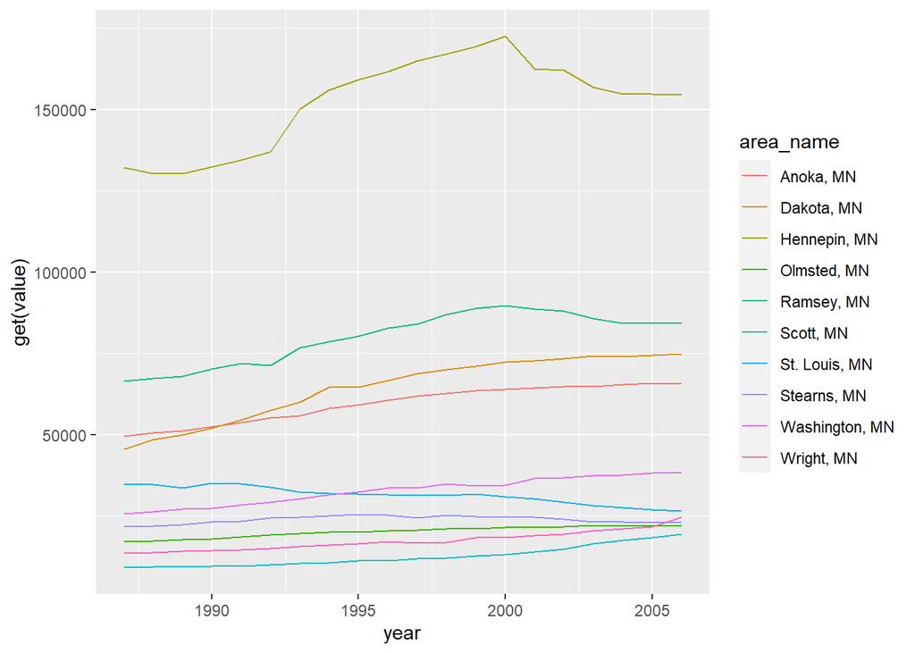

```r
plot.county(combined_tib$county, state = "MN", top = 10)
```

## Four total URLS

Now we will apply our data processing function to the following four .csv files (data sets)

```r
PST01a <- my_wrapper("https://www4.stat.ncsu.edu/~online/datasets/PST01a.csv")
PST01b <- my_wrapper("https://www4.stat.ncsu.edu/~online/datasets/PST01b.csv")
PST01c <- my_wrapper("https://www4.stat.ncsu.edu/~online/datasets/PST01c.csv")
PST01d <- my_wrapper("https://www4.stat.ncsu.edu/~online/datasets/PST01d.csv")
```

## Combine four URLS

As with the two previous data sets, we will want to convert these four processed data sets into one data object. We can combine two at a time with the combine_tibbles() function, which means we will need to run it three times–the latter two times on data objects containing the latest combined tibble iteration.

```r
# Now run data combing function to store the processed objects as a single object
intermediatePSTab <- combine_tibbles(PST01a, PST01b)
intermediatePSTabc <- combine_tibbles(intermediatePSTab, PST01c)
PST01abcd <- combine_tibbles(intermediatePSTabc, PST01d)
PST01abcd
```

[output not shown]

## Plot state data frame

Below we plot the state tibble of PST01abcd (the combined tibble found above) with plot.state() that we created.

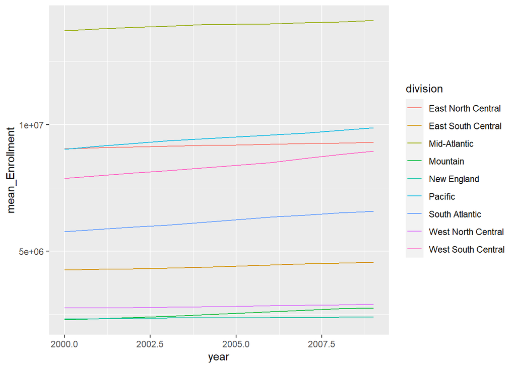

```r
plot.state(PST01abcd$state)
```

## Testing plot.county again

Let us now test plot.county() function on the county data frame.

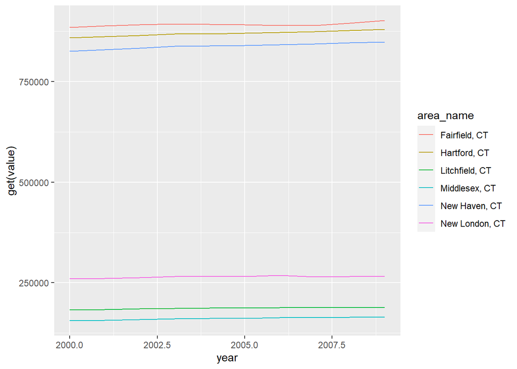

```r
plot.county(PST01abcd$county, state = "CT", top = 6)
```

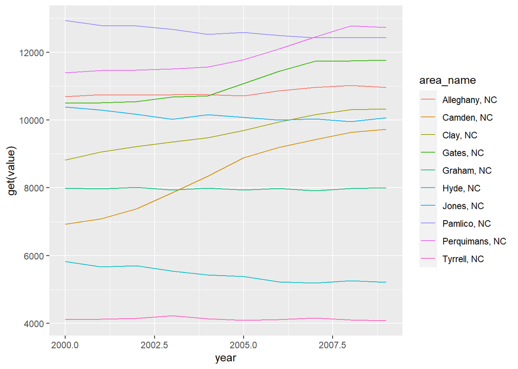

```r
plot.county(PST01abcd$county, state = "NC", top = -10)
```

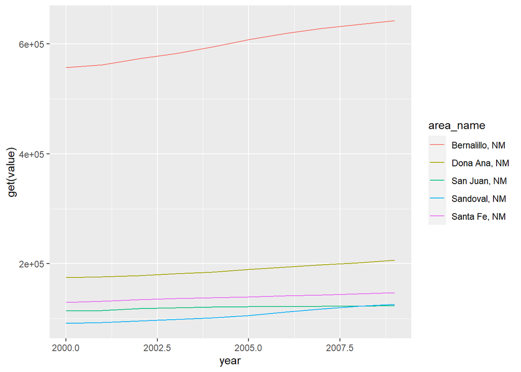

```r
plot.county(PST01abcd$county)
```

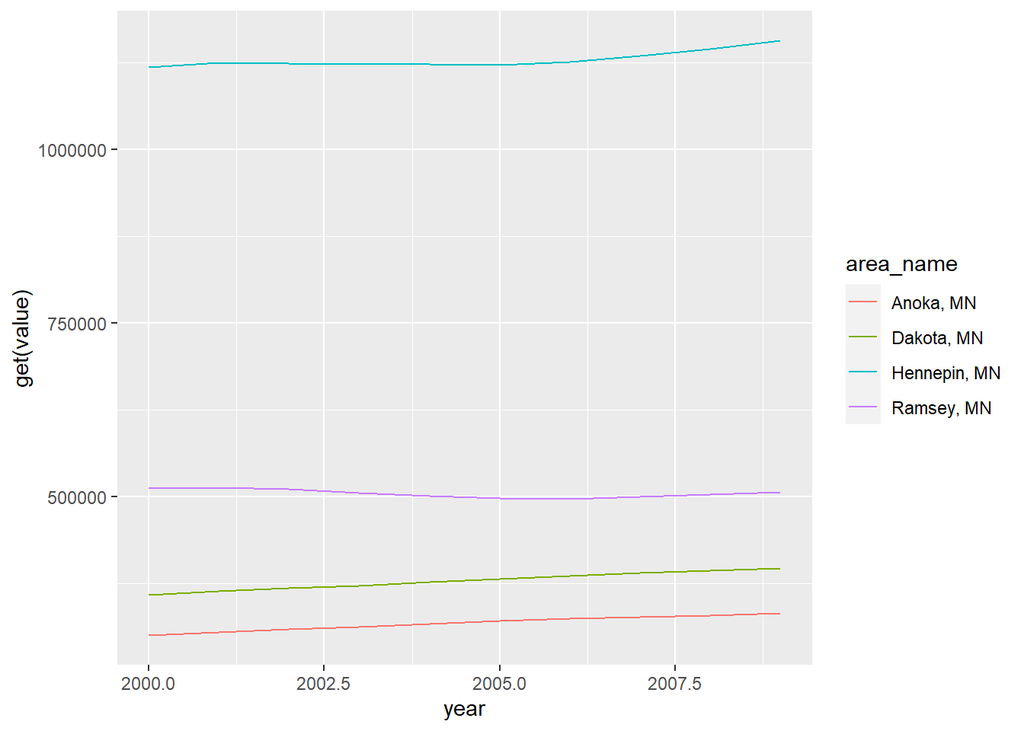

```r
plot.county(PST01abcd$county, state = "MN", top = 4)
```